# Functions

Version 0.4 - November 2021

[figure not shown]

The `mtqgam` package was created to simplify working with mouse-tracking data in QGAMs. Aiding the [ENGS](https://www.spoken-morphology.hhu.de/en/projects/engs-final-s-in-english-the-role-of-acoustic-detail-in-morphological-processing-and-learning) and the [VAR](https://www.spoken-morphology.hhu.de/en/projects/var-morpho-phonetic-variation-in-english) project of the [DFG-FOR 2373 “Spoken Morphology”](https://www.spoken-morphology.hhu.de/) research unit, this package is under development.

This vignette gives an overview of functions included in the `mtqgam` package. Please contact the author in case of questions.

# Overview

This is a full list of all functions currently contained in `mtqgam`:

- better_parametric_plot - Better Parametric Plots
- better_smooth_plot - Better Smooth Plots
- better_interaction_plot - Better Interaction Plots
- facet_parametric_plot - Multi-Panel Parametric Plots
- facet_smooth_plot - Multi-Panel Smooth Plots
- extract_t - Extract t Coordinates
- extract_x - Extract x Coordinates
- extract_y - Extract y Coordinates

Note: Due to size reasons, no exemplary data set is included in this package.

# Better Parametric Plots

The `better_parametric_plot` function creates a point-range plot for the specified parametric predictor term. It basically is a wrapper for `itsadug`’s `plot_parametric` function, adding the variability and flexibility of `ggplot2` objects.

The functions requires a QGAM model. The QGAM model can either be the output of `qgam::qgam`, the output of `qgam::mqgam`, or a single QGAM model extracted from a `qgam::mqgam` object. Specify the quantile you wish to plot when using the output of `qgam::mqgam`. In all cases, the `pred` argument is required. This is the parametric effect you wish to plot.

## An ‘Old’ Parametric Plot

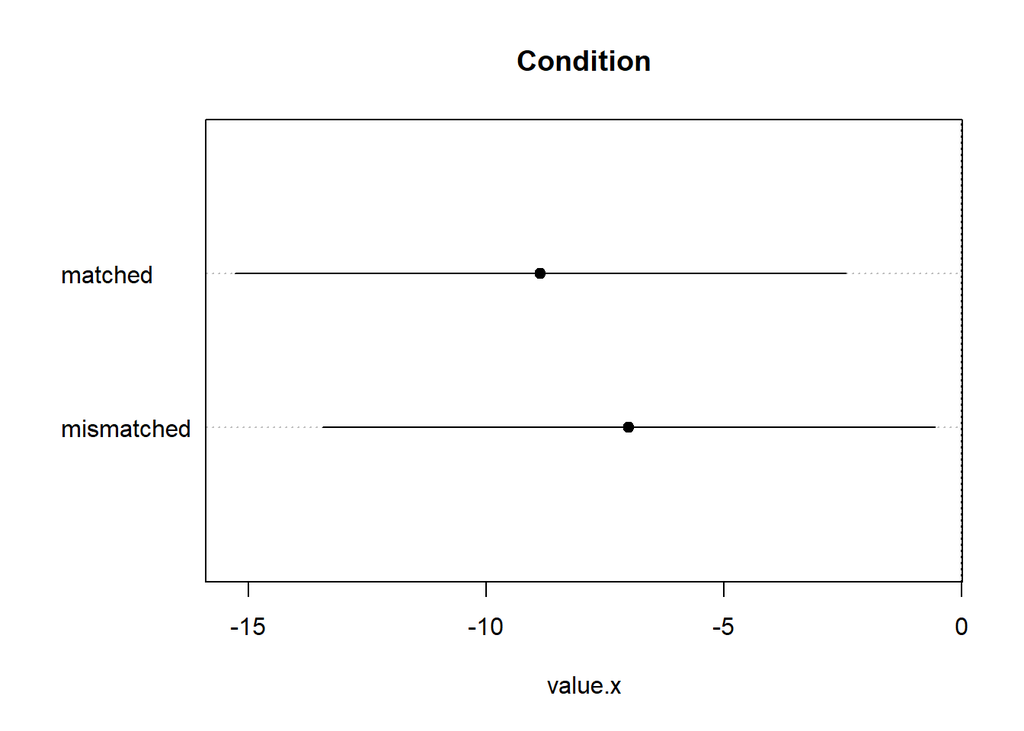

```r
old.plot <- plot_parametric(tmp.x.1,
                            pred = list(Condition = c("matched", "mismatched")),
                            print.summary=F)
```

## A Better Parametric Plot

### using a single QGAM extracted from a `qgam::mqgam` object OR created using `qgam::qgam`

```
#> i Plotting predictor Condition with default order of predictor levels.
```

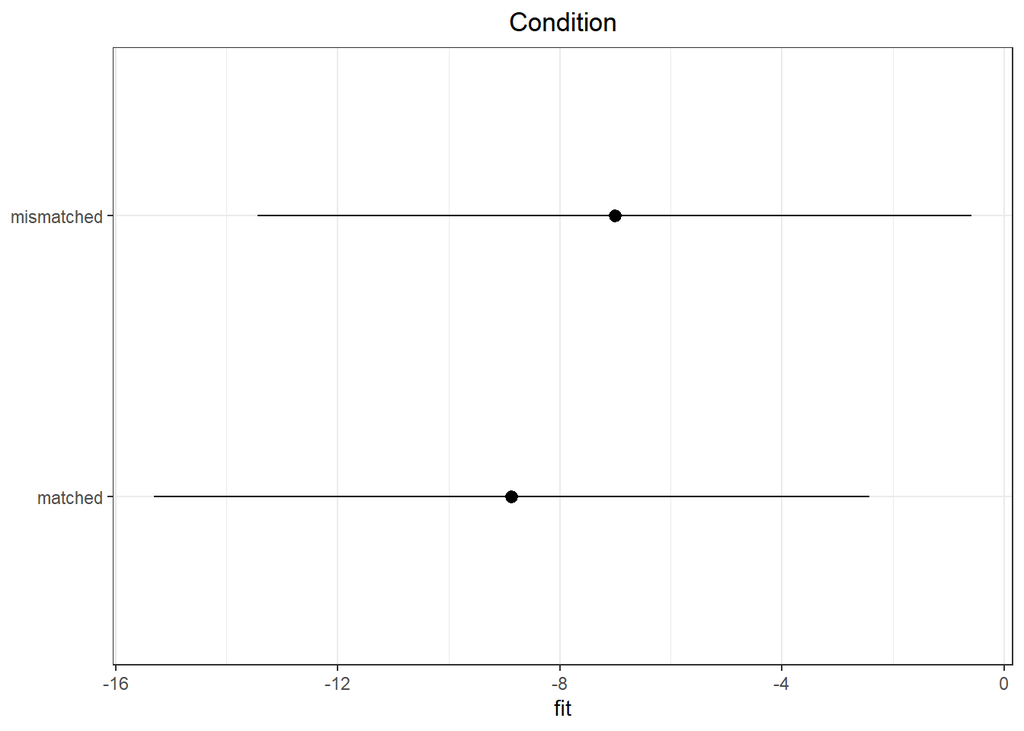

```r
better_parametric_plot(qgam = tmp.x.1, pred = "Condition")
```

### using the output of `qgam::mqgam`

```
#> i Plotting predictor Condition with default order of predictor levels.
```

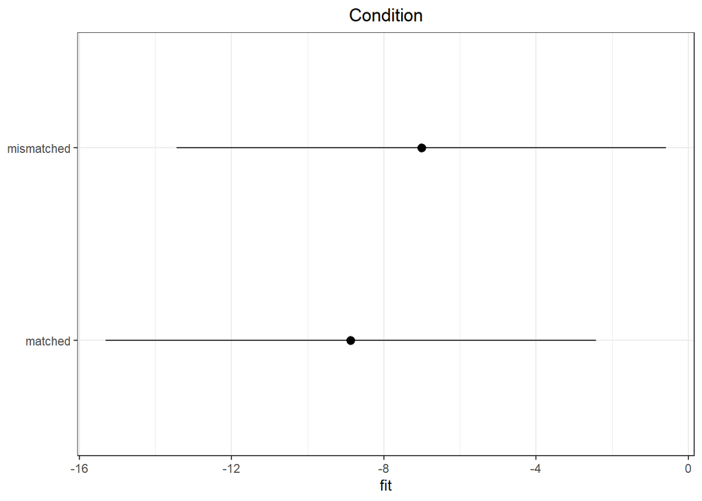

```r
better_parametric_plot(qgam = qgams_x, quantile = 0.5, pred = "Condition")
```

### Modifications

You can change the order of the predictor levels displayed on the y axis:

```
#> i Plotting predictor Condition with specified order of predictor levels.
```

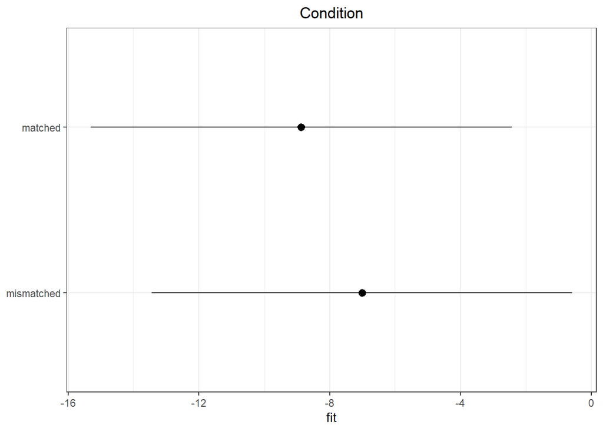

```r
better_parametric_plot(qgam = tmp.x.1, pred = "Condition",
                       order = c("mismatched", "matched"))
```

Plots created with `better_parametric_plot` can be modified using common `ggplot2` functions:

```
#> i Plotting predictor Condition with default order of predictor levels.
```

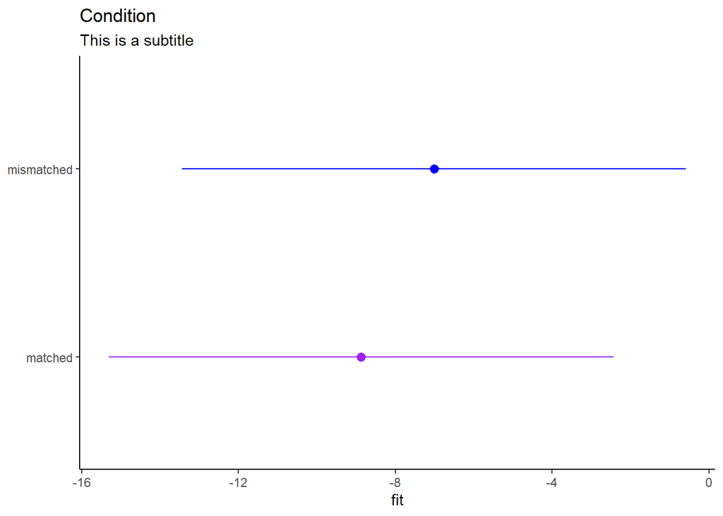

```r
better_parametric_plot(qgam = tmp.x.1, pred = "Condition",
                       color = c("purple", "blue")) +
                       theme_classic() +
                       labs(subtitle = "This is a subtitle")
```

# Better Smooth Plots

The functions requires a QGAM model. The QGAM model can either be the output of `qgam::qgam`, the output of `qgam::mqgam`, or a single QGAM model extracted from a `qgam::mqgam` object. Specify the quantile you wish to plot when using the output of `qgam::mqgam`. In all cases, the `pred` argument is required. This is the smooth you wish to plot.

Note: In previous versions, `smooth_term` was specified instead of `pred` instead. This argument is now obsolete. Please use `pred` instead.

## An ‘Old’ Smooth Plot

```r
old.plot <- plot(tmp.x.1,
                 select = 6)
```

[output not shown]

## A Better Smooth Plot

### using a single QGAM extracted from a `qgam::mqgam` object OR created using `qgam::qgam`

```
#> i Plotting smooth term PIT.
```

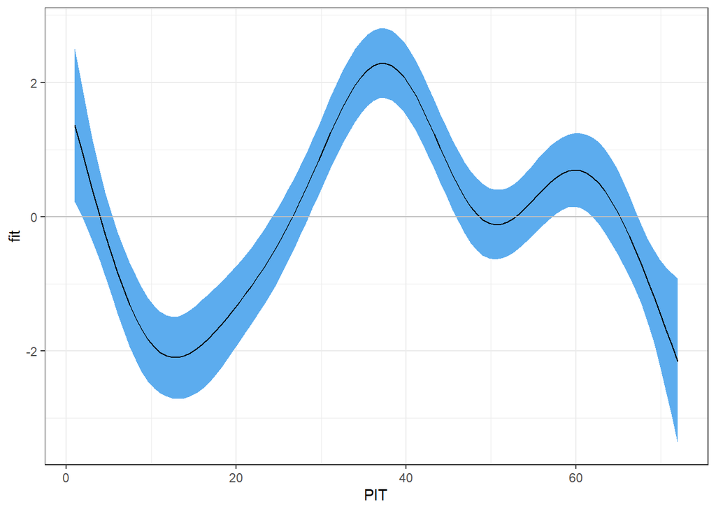

```r
better_smooth_plot(qgam = tmp.x.1, pred = "PIT")
```

### using the output of `qgam::mqgam`

```
#> i Plotting smooth term PIT.
```

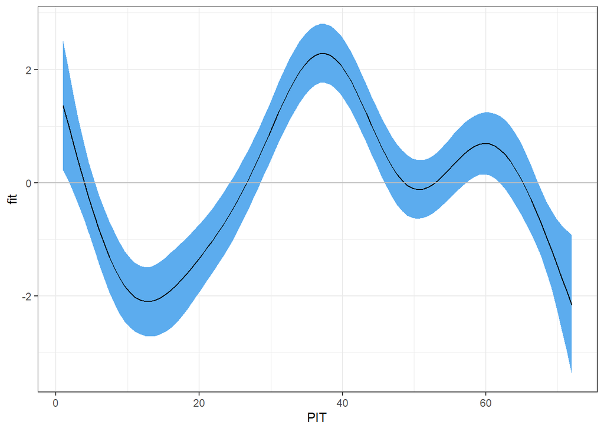

```r
better_smooth_plot(qgam = qgams_x, quantile = 0.5, pred = "PIT")
```

### Modifications

Plots created with `better_smooth_plot` can be modified using common `ggplot2` functions:

```
#> i Plotting smooth term PIT.
```

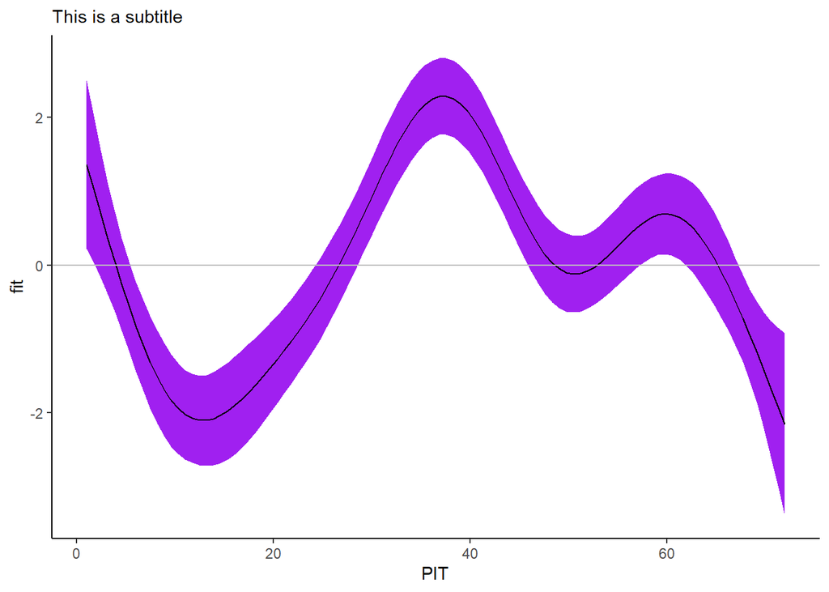

```r
better_smooth_plot(qgam = tmp.x.1, pred = "PIT",
                   fill = "purple") +
                   theme_classic() +
                   labs(subtitle = "This is a subtitle")
```

# Better Interaction Plots

The `better_interaction_plot` function creates either a smooth plot with confidence intervals (for numeric:factor interactions) or a point plot with confidence interval ranges (for factor:factor interactions) using `ggplot2.` The underlying functions are similar to `better_parametric_plot` and `better_smooth_plot` (as introduced above). Using similar underlying functions, `better_interaction_plot` adds the variability and flexibility of `ggplot2` to plots of interactions.

The functions requires a QGAM model. The QGAM model can either be the output of `qgam::qgam`, the output of `qgam::mqgam`, or a single QGAM model extracted from a `qgam::mqgam` object. Specify the quantile you wish to plot when using the output of `qgam::mqgam`. In all cases, the `pred` and the `cond` argument are required. `pred` is the parametric effect you wish to plot; `cond` is either the (parametric or smooth) term `pred` is in interaction with.

## factor:factor Interaction Plots

The `better_interaction_plot` automatically checks whether the variable given as `pred` input is numeric or a factor. In case of factors, plots of the following type are created.

### using a single QGAM extracted from a `qgam::mqgam` object OR created using `qgam::qgam`

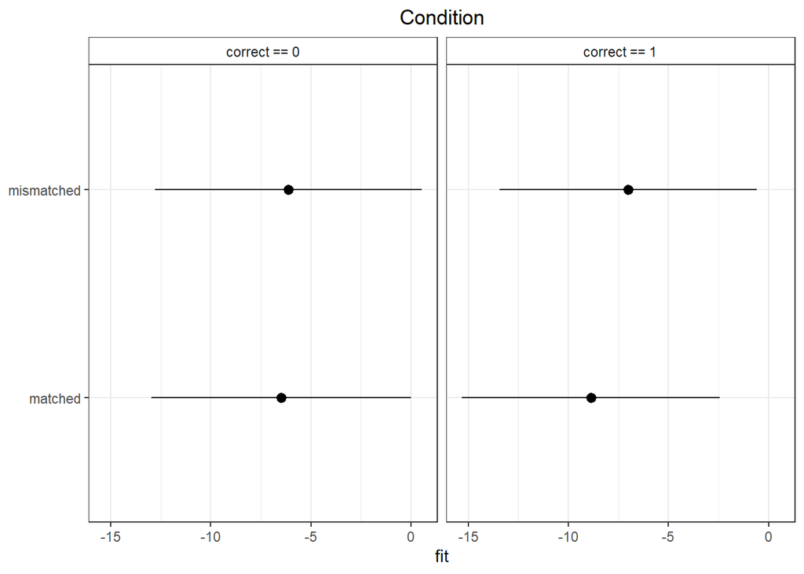

```r
better_interaction_plot(qgam = tmp.x.1, pred = "Condition", cond = "correct")
```

### using the output of `qgam::mqgam`

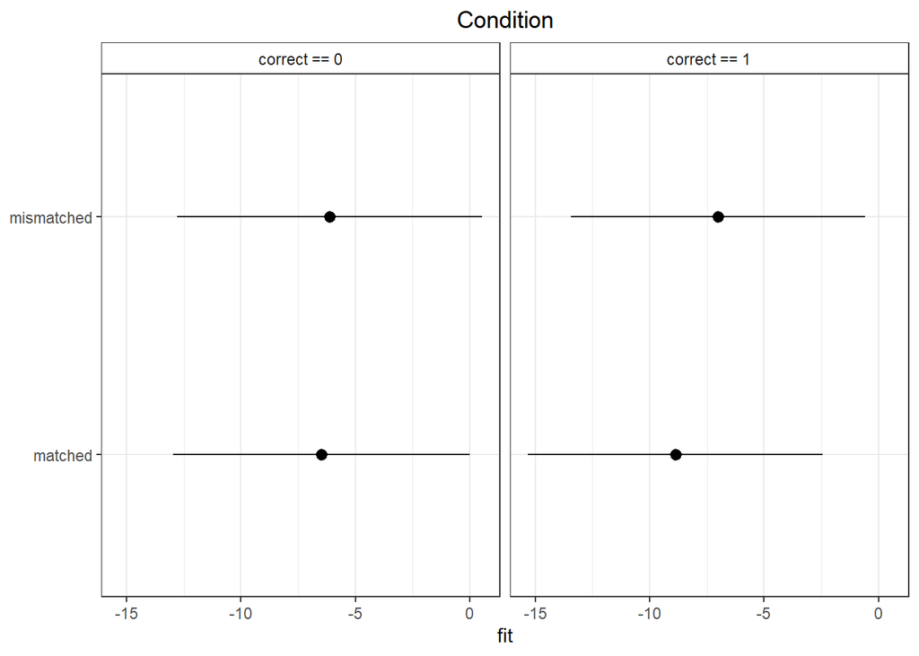

```r
better_interaction_plot(qgam = qgams_x, quantile = 0.5, pred = "Condition", cond = "correct")
```

### Modifications

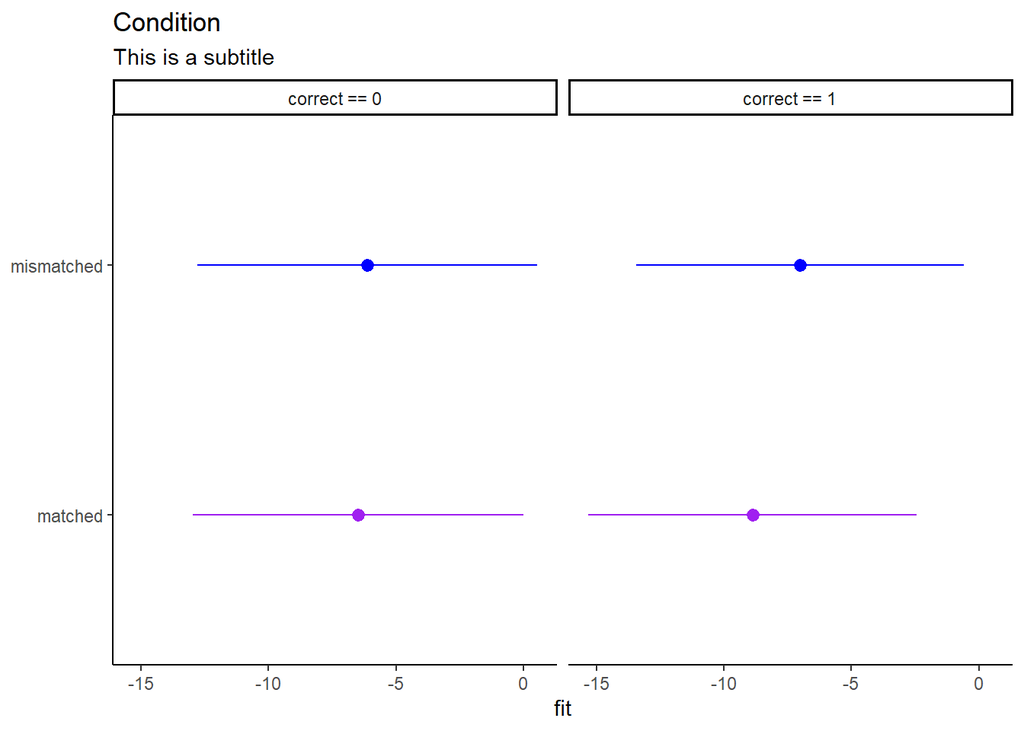

```r
better_interaction_plot(qgam = qgams_x, quantile = 0.5, pred = "Condition", cond = "correct",
                        color = c("purple", "blue")) +
                        theme_classic() +
                        labs(subtitle = "This is a subtitle")
```

## numeric:factor Interaction Plots

The `better_interaction_plot` automatically checks whether the variable given as `pred` input is numeric or a factor. In case of numeric variables, plots of the following type are created. By default, these plots are presented in facets.

### using a single QGAM extracted from a `qgam::mqgam` object OR created using `qgam::qgam`

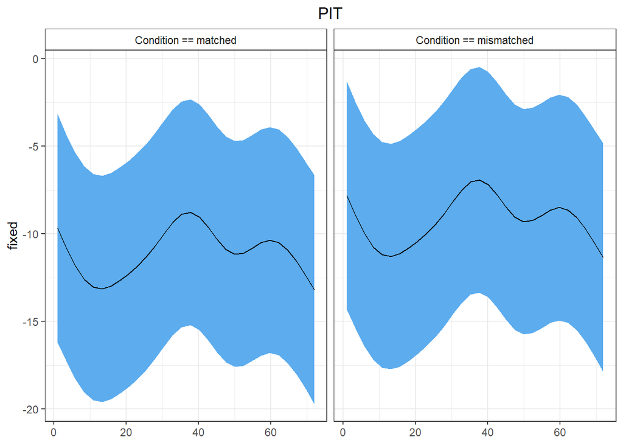

```r
better_interaction_plot(qgam = tmp.x.1, pred = "PIT", cond = "Condition")
```

### using the output of `qgam::mqgam`

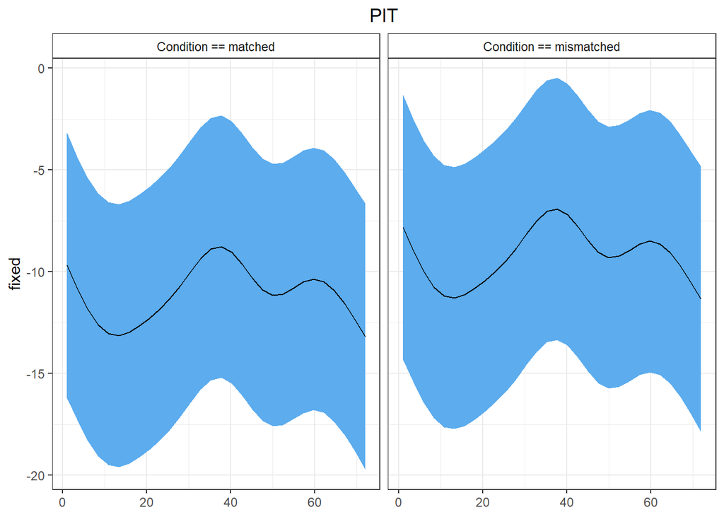

```r
better_interaction_plot(qgam = qgams_x, quantile = 0.5, pred = "PIT", cond = "Condition")
```

### Modifications

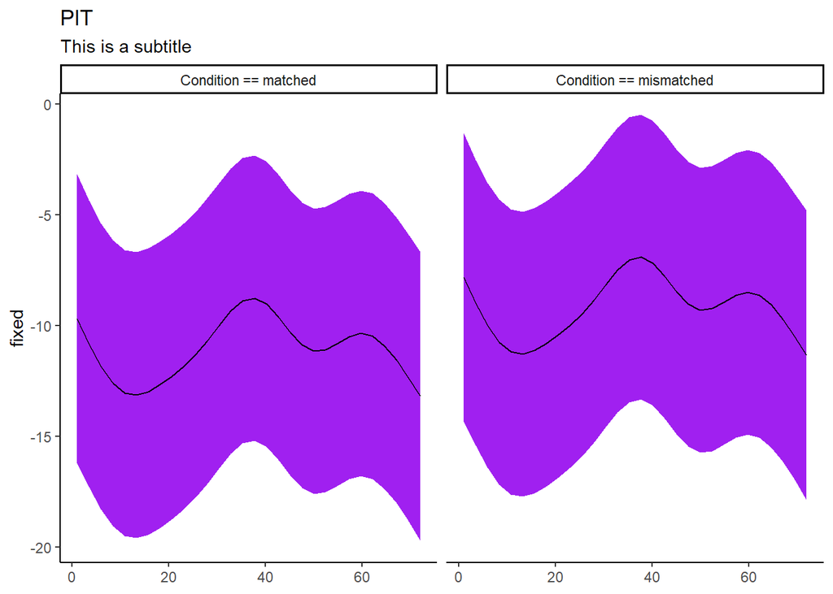

```r
better_interaction_plot(qgam = qgams_x, quantile = 0.5, pred = "PIT", cond = "Condition",
                        fill = "purple") +
                        theme_classic() +
                        labs(subtitle = "This is a subtitle")
```

### `no_facet` Plots

Interactions of type numeric:factor can also be plotted in a single plot. To achieve this, specify the `type` argument as `no_facet`.

```
#> ! Changing alpha to 0.5 for better legibility.
```

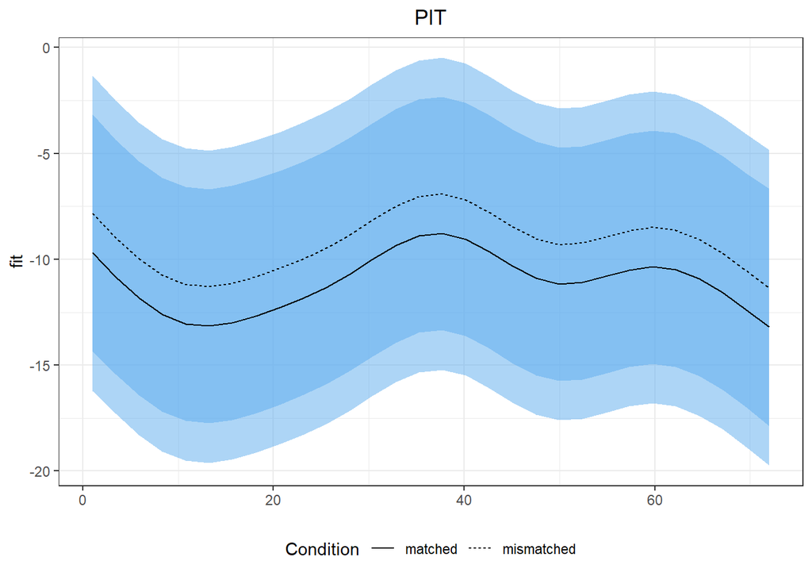

```r
better_interaction_plot(qgam = tmp.x.1, pred = "PIT", cond = "Condition", type = "no_facet")
```

# Multi-Panel Parametric Plots

The `facet_parametric_plot` function creates a multi-panel plot of `better_parametric_plots`.

The functions requires a collection of QGAM models. The QGAM models should be the output of `qgam::mqgam`. Additionally, the `pred` argument is required. This is the parametric effect you wish to plot.

## A Multi-Panel Parametric Plot

```
#> i Plotting with default order of predictor levels.
```

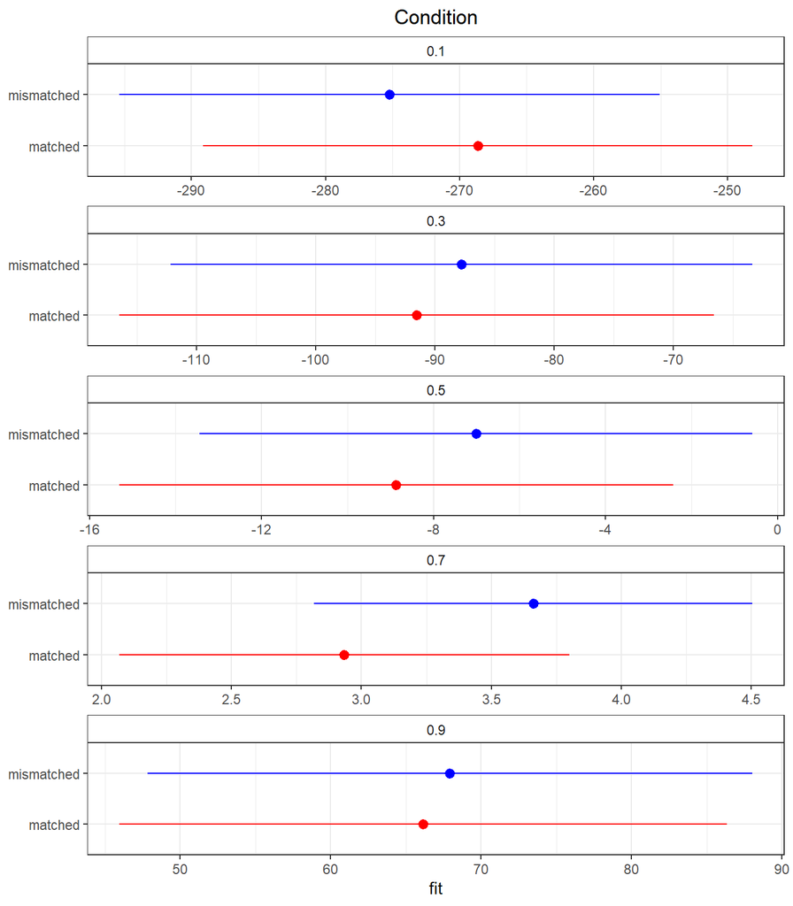

```r
facet_parametric_plot(qgam = qgams_x, pred = "Condition")
```

## Modifications

Plots created with `facet_parametric_plot` have standard colors for levels of the `pred` argument. These, of course, can be changed:

```
#> i Plotting with default order of predictor levels.
```

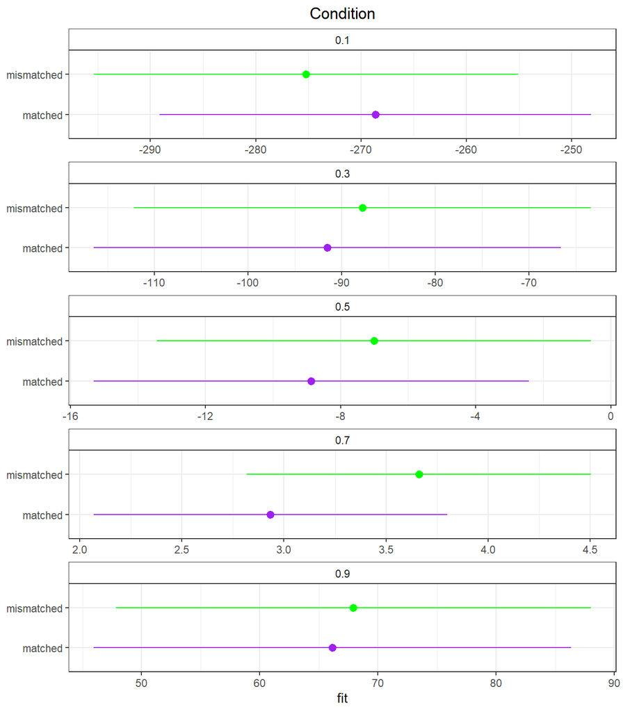

```r
facet_parametric_plot(qgam = qgams_x, pred = "Condition",
                      color = c("purple", "green"))
```

Plots created with `facet_parametric_plot` can be modified using common `ggplot2` functions:

```
#> i Plotting with default order of predictor levels.
```

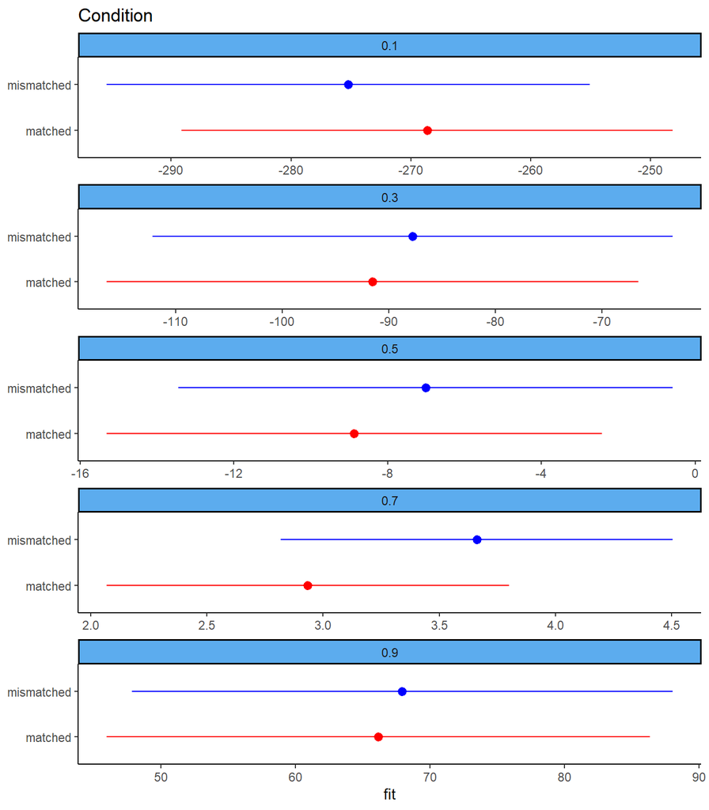

```r
facet_parametric_plot(qgam = qgams_x, pred = "Condition") +
                   theme_classic() +
                   theme(strip.background = element_rect(fill = "steelblue2"))
```

Plots created with `facet_parametric_plot` use a free scale, i.e. the scale of the axes of the individual facets is adapted to the range of its values. This can be changed by specifying the `scale` argument:

```
#> i Plotting with default order of predictor levels.
```

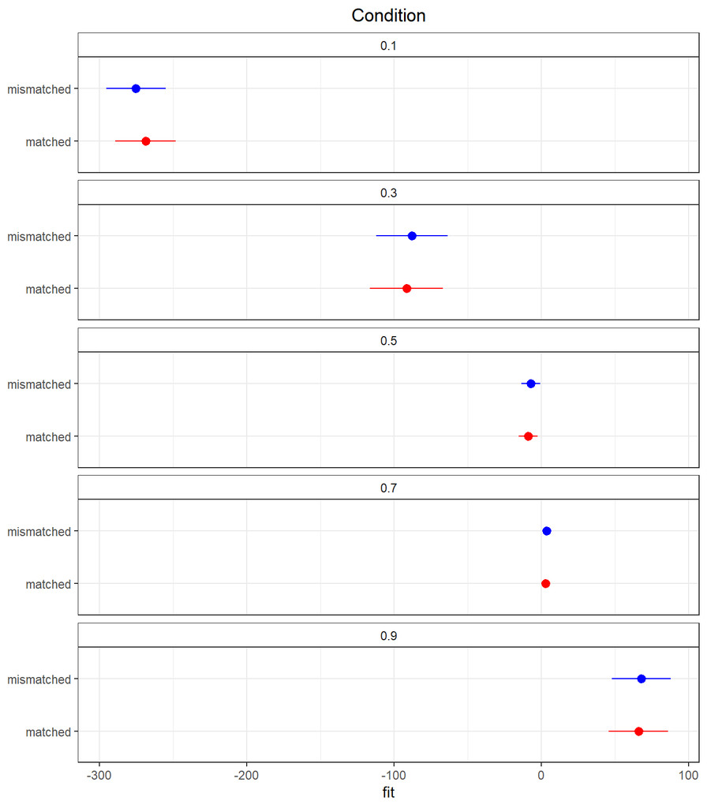

```r
facet_parametric_plot(qgam = qgams_x, pred = "Condition",
                      scale = "fixed")
```

# Multi-Panel Smooth Plots

The `facet_smooth_plot` function creates a multi-panel plot of `better_smooth_plots`.

The functions requires a collection of QGAM models. The QGAM models should be the output of `qgam::mqgam`. Additionally, the `pred` argument is required. This is the smooth you wish to plot.

```
#> i Plotting multi-panel plot for smooth term PIT.
```

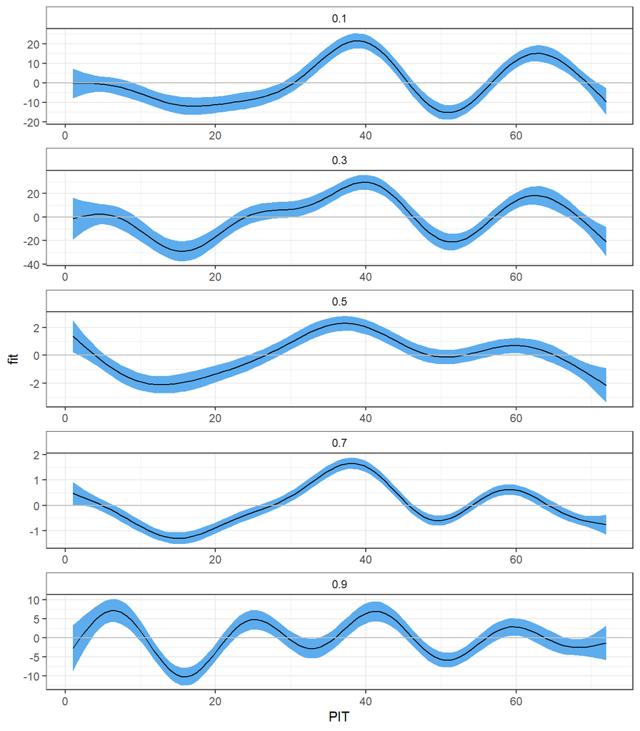

```r
facet_smooth_plot(qgam = qgams_x, pred = "PIT")
```

## Modifications

Plots created with `facet_smooth_plot` have a standard color for the confidence interval of the `pred` argument. This color, of course, can be changed:

```
#> i Plotting multi-panel plot for smooth term PIT.
```

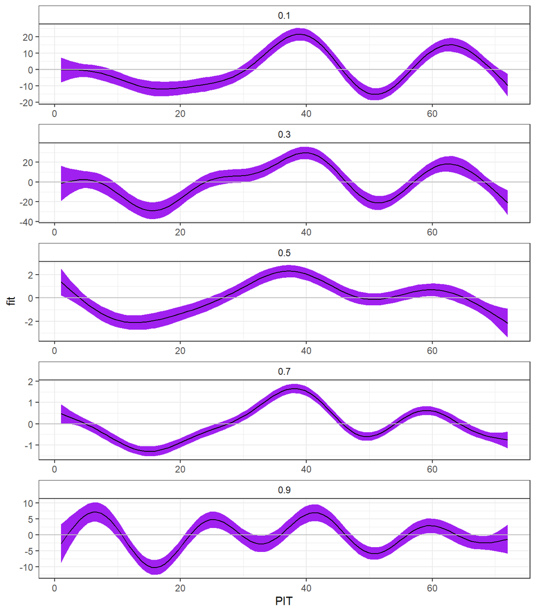

```r
facet_smooth_plot(qgam = qgams_x, pred = "PIT",
                      fill = "purple")
```

Plots created with `facet_smooth_plot` can be modified using common `ggplot2` functions:

```
#> i Plotting multi-panel plot for smooth term PIT.
```

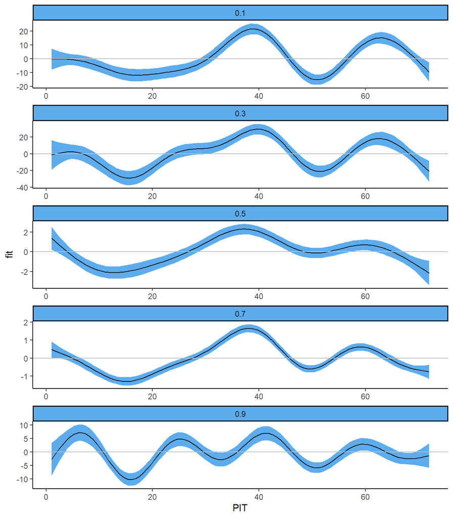

```r
facet_smooth_plot(qgam = qgams_x, pred = "PIT") +
                   theme_classic() +
                   theme(strip.background = element_rect(fill = "steelblue2"))
```

Plots created with `facet_smooth_plot` use a free scale, i.e. the scale of the axes of the individual facets is adapted to the range of its values. This can be changed by specifying the `scale` argument:

```
#> i Plotting multi-panel plot for smooth term PIT.
```

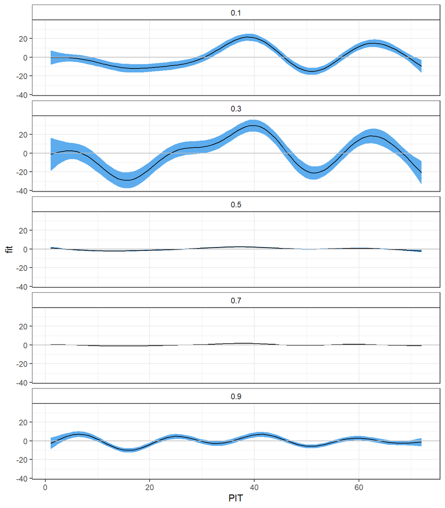

```r
facet_smooth_plot(qgam = qgams_x, pred = "PIT",
                      scale = "fixed")
```